# MEI alignment starting bases

Reads sequenced with ONT were aligned to the mobile elements shown below.  
The Bio.Align Python package was used to find local alignments and alignments were filtered  
to include only those which aligned starting at the beginning of the read and received an alignment score >= 100.

### L1 flongle reads

Reads were combined using results from the NA12878 experiments.  
Total reads: 28,695  
Reads passing filters: 1,923  
Reads shown in plot, within reduced range: 1,672

Labels on bars are the starting base of the alignment, relative to the L1HS sequence.

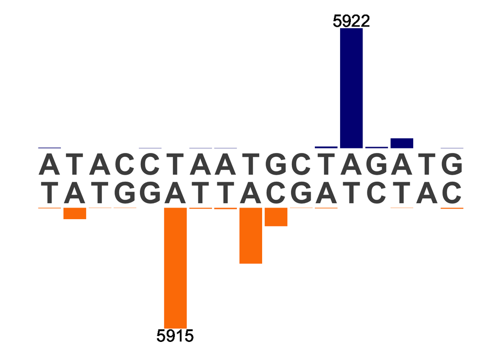

### L1 minION reads

Reads were combined using results from the NA12878 experiments.  
Total reads: 107,778  
Reads passing filters: 504  
Reads shown in plot, within reduced range: 321

Labels above the bars represent the alignment starting base relative to the L1HS sequence on the reverse strand (since almost all reads aligned to the reverse strand).  
Only 1 read of the 321 that are plotted here was aligned to the forward strand within this range.

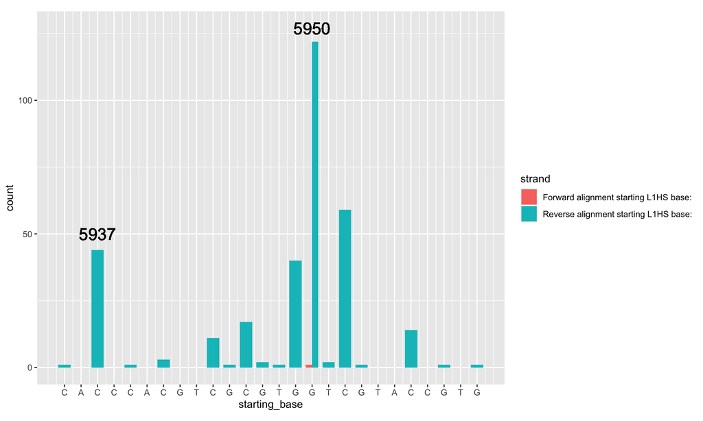

### AluYa5 reads

Total reads: 1,061  
Reads passing filters: 6

|  | strand | starting_base |
| --- | --- | --- |
| 6 | Forward alignment starting L1HS base: | 282 |
| 3 | Reverse alignment starting L1HS base: | 5811 |
| 1 | Reverse alignment starting L1HS base: | 6002 |
| 4 | Reverse alignment starting L1HS base: | 6011 |
| 2 | Reverse alignment starting L1HS base: | 6013 |
| 5 | Reverse alignment starting L1HS base: | 6017 |

### AluYb8 reads

Total reads: 262  
Reads passing filters: 2

|  | strand | starting_base |
| --- | --- | --- |
| 2 | Forward alignment starting L1HS base: | 222 |
| 1 | Reverse alignment starting L1HS base: | 6025 |

### SVA_E

Total reads: 13,891  
Reads passing filters: 14

| strand | starting_base | n |
| --- | --- | --- |
| Forward alignment starting L1HS base: | 212 | 1 |
| Forward alignment starting L1HS base: | 222 | 1 |
| Forward alignment starting L1HS base: | 301 | 1 |
| Forward alignment starting L1HS base: | 313 | 3 |
| Forward alignment starting L1HS base: | 344 | 1 |
| Forward alignment starting L1HS base: | 350 | 1 |
| Reverse alignment starting L1HS base: | 4742 | 1 |
| Reverse alignment starting L1HS base: | 4916 | 1 |
| Reverse alignment starting L1HS base: | 4925 | 1 |
| Reverse alignment starting L1HS base: | 4944 | 1 |

[output cut: 2 more lines]

### SVA_F

Total reads: 43,092  
Reads passing filters: 94

| strand | starting_base | n |
| --- | --- | --- |
| Forward alignment starting L1HS base: | 58 | 2 |
| Forward alignment starting L1HS base: | 140 | 2 |
| Forward alignment starting L1HS base: | 142 | 2 |
| Forward alignment starting L1HS base: | 236 | 2 |
| Forward alignment starting L1HS base: | 291 | 2 |
| Forward alignment starting L1HS base: | 302 | 4 |
| Forward alignment starting L1HS base: | 312 | 2 |
| Forward alignment starting L1HS base: | 341 | 2 |
| Forward alignment starting L1HS base: | 387 | 2 |
| Forward alignment starting L1HS base: | 991 | 2 |

[output cut: 33 more lines]